# PA1_template

Biscuit7

2017-07-14

# Analyzing Step Data from an Activity Monitoring Device

This project is part of the Reproducible Research course in Coursera’s Data Science specialisation track. The purpose of the project is to analyse data collected from a FitBit by way of:

- loading and preprocessing data
- drawing time series plots and histograms
- imputing missing values
- interpreting data to answer research questions

## Loading and preprocessing the data

### Read activity data and remove missing values

```r
df <- read.csv("activity.csv",header=T,na.strings = "NA")
df1 <- df[!is.na(df$steps),]
```

## What is mean total number of steps taken per day?

### Histogram

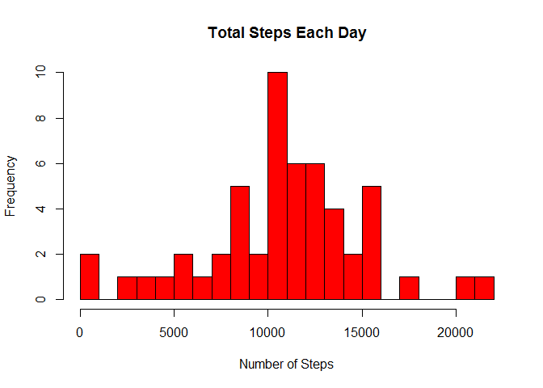

```r
total <- aggregate(steps ~ date, df1, sum)
hist(total$steps, breaks=20, main="Total Steps Each Day", col="red", xlab="Number of Steps")
```

```r
step_mean <- round(mean(total$steps),2)
step_median <- median(total$steps)
```

## What is the average daily activity pattern?

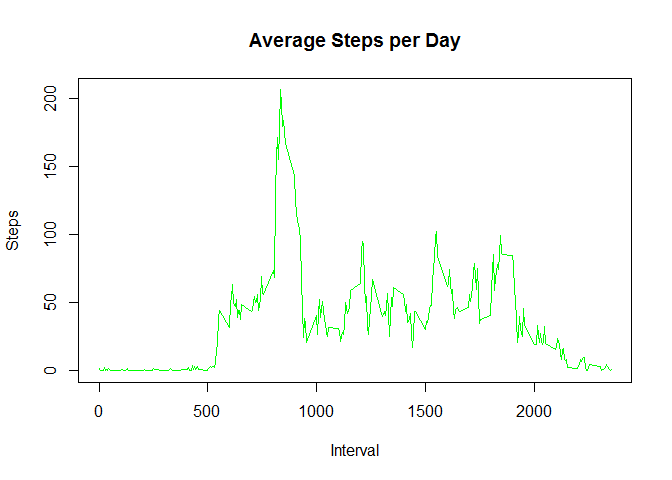

```r
avg_steps <- aggregate(steps ~ interval, df1, mean)
avg_steps$day <- seq.int(nrow(avg_steps))
plot(avg_steps$interval, avg_steps$steps, type="l", main="Average Steps per Day", col="green",
     xlab="Interval", ylab="Steps")
```

### The 5-minute interval with the maximum number of steps, on average

```r
avg_int <- aggregate(steps ~ interval, df1, mean)
max_int <- avg_int[avg_int$steps==max(avg_int$steps),"interval"]
```

The `interval` with the maximum number of steps, on average, is 835.

## Imputing missing values

### Number of records with missing values

```r
sum(is.na(df))
```

```
## [1] 2304
```

There are 2304 `missing values`.

### Imputing

Imputation will involve filling in the missing values with the mean number of steps per interval, which is assigned to `avg_int`.

```r
df_new <- df
avg  <- tapply(df_new$steps, df_new$interval, mean, na.rm=T, simplify=T)
df_new$steps[is.na(df_new$steps)] <- avg[as.character(df_new$interval[is.na(df_new$steps)])]
```

### Histogram with imputed values

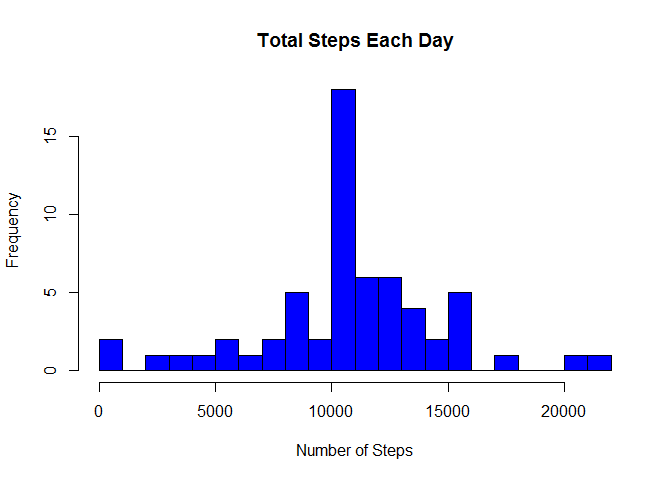

```r
total_new <- aggregate(steps ~ date, df_new, sum)
hist(total_new$steps, breaks=20, main="Total Steps Each Day", col="blue", xlab="Number of Steps")
```

```r
new_mean <- round(mean(total_new$steps),2)
new_median <- median(total_new$steps)
```

## Are there differences in activity patterns between weekdays and weekends?

### Panel plot comparing weekdays and weekends

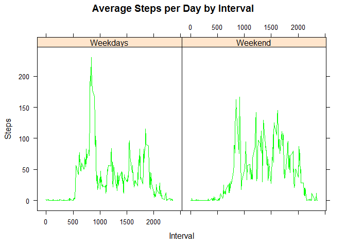

```r
weekend <- c("Saturday", "Sunday")
df_new$day = as.factor(ifelse(is.element(weekdays(as.Date(df_new$date)),weekend), "Weekend", "Weekdays"))
total_day <- aggregate(steps ~ interval + day, df_new, mean)
xyplot(total_day$steps ~ total_day$interval|total_day$day, col="green", main="Average Steps per Day by Interval", xlab="Interval", ylab="Steps",layout=c(2,1), type="l")
```